# Modelling-ByCustomer

```python
##########################################
# This notebook is used for intial data exploration for the capstone project
##########################################
```

```python
import sklearn

print('The scikit-learn version is {}.'.format(sklearn.__version__))
# All code tested on 0.18.1, which is needed for sklearn.neural_network/MLPClassifier
```

```
The scikit-learn version is 0.18.1.
```

First, we import the data

```python
import pandas as pd
import numpy as np
import glob
from IPython.display import display # Allows the use of display() for DataFrames


#data = pd.read_csv('data/transactions_200607.csv')  #import one file

#import all csvs (courtesy of http://stackoverflow.com/questions/20906474/import-multiple-csv-files-into-pandas-and-concatenate-into-one-dataframe)

path =r'data' # use your path
allFiles = glob.glob(path + "/tr*.csv")

#print allFiles
data = pd.DataFrame()
list_ = []
for file_ in allFiles:
    df = pd.read_csv(file_,index_col=None, header=0)
    list_.append(df)
data = pd.concat(list_)

#print(data.head(20))


print('Before DropNA',len(data))
data=data.dropna()
print('After DropNA',len(data))

#consider dropping these categories, but will try with them first.

#data = data[data.CUST_PRICE_SENSITIVITY != 'XX']
#data = data[data.CUST_LIFESTAGE != 'OT']
#print('After Uninteresting categories',len(data))
#list(data.columns.values)
```

```
('Before DropNA', 31057875)
('After DropNA', 21967768)
```

Reformat the data into a wide dataset using Prod_code_20 as the lowest level of aggregation. This is as recommended by Apeh et al. in Customer Profile Classification Using Transactional Data (https://core.ac.uk/download/pdf/4899037.pdf). Then, to predict the basket, we just apply the value for the predicted customer.

```python
#create customerprofiles.  Simplest version will be to sum spend in each category in PROD_CODE_20, keeping the target variable as well
#pivot code from http://stackoverflow.com/questions/41046766/using-and-graphing-the-results-of-a-crosstab-dataframe-in-python

data_cross=data.pivot_table(index='CUST_CODE', columns='PROD_CODE_20', values='SPEND', aggfunc=np.sum, fill_value=0)
data_cross.reset_index(level=['CUST_CODE'], inplace=True)

#group the variables that are unique to each basket
byCustomer=data.groupby(['CUST_CODE'])
targetsByCustomer=pd.DataFrame(byCustomer['CUST_LIFESTAGE', 'CUST_PRICE_SENSITIVITY'].first())
targetsByCustomer.reset_index(level=['CUST_CODE'], inplace=True)

sumsByCustomer=pd.DataFrame(byCustomer['SPEND'].sum())
sumsByCustomer.reset_index(level=['CUST_CODE'], inplace=True)

data_cross_day=data.pivot_table(index='CUST_CODE', columns='SHOP_WEEKDAY', values='SPEND', aggfunc=np.sum, fill_value=0)
data_cross_day.reset_index(level=['CUST_CODE'], inplace=True)
data_cross_hour=data.pivot_table(index='CUST_CODE', columns='SHOP_HOUR', values='SPEND', aggfunc=np.sum, fill_value=0)
data_cross_hour.reset_index(level=['CUST_CODE'], inplace=True)
data_cross_basketsize = data.pivot_table(index='CUST_CODE', columns='BASKET_SIZE', values='SPEND', aggfunc=len, fill_value=0)
data_cross_basketsize.reset_index(level=['CUST_CODE'], inplace=True)
data_cross_baskettype = data.pivot_table(index='CUST_CODE', columns='BASKET_TYPE', values='SPEND', aggfunc=len, fill_value=0)
data_cross_baskettype.reset_index(level=['CUST_CODE'], inplace=True)


data_cross = pd.merge(data_cross, data_cross_day, how='inner', on = 'CUST_CODE')
data_cross = pd.merge(data_cross, data_cross_hour, how='inner', on = 'CUST_CODE')
data_cross = pd.merge(data_cross, data_cross_basketsize, how='inner', on = 'CUST_CODE')
data_cross = pd.merge(data_cross, data_cross_baskettype, how='inner', on = 'CUST_CODE')

data_cross = pd.merge(data_cross, sumsByCustomer, how='inner', on = 'CUST_CODE')
data_cross = pd.merge(data_cross, targetsByCustomer, how='inner', on = 'CUST_CODE')

#reset the index to what it should be for the rest of the analysis
data_cross.set_index(['CUST_CODE'], inplace=True)

print(data_cross.head(5))
#list(data_cross.columns.values)
#print(data_cross.describe(include='all'))
```

```
                DEP00001  DEP00002  DEP00003  DEP00004  DEP00005  DEP00006  \
CUST_CODE
CUST0000000031     14.41     19.62      1.39     21.96     13.28       0.0
CUST0000000068    266.45     50.44     71.24      1.68      6.86       0.0
CUST0000000108      0.00      0.00      4.32      0.00      0.00       0.0
CUST0000000131      2.34     30.37      0.00      4.86      2.46       0.0
CUST0000000164      2.34      0.00      0.00      0.00      0.00       0.0

                DEP00007  DEP00008  DEP00009  DEP00010  \
CUST_CODE
CUST0000000031       0.0    111.16      3.21     34.87
CUST0000000068       0.0    153.07      2.56     11.08
CUST0000000108       0.0      1.76      0.00      2.98
CUST0000000131       0.0    130.05      2.78     30.59
CUST0000000164       0.0      2.77      0.00      1.29

                         ...               L    M   S  Full Shop  Small Shop  \
CUST_CODE                ...
CUST0000000031           ...             301  294  62         44         268
CUST0000000068           ...            1028  285  71        333         334
CUST0000000108           ...               0   12   0          0           0
CUST0000000131           ...             255   92  17        179          75
CUST0000000164           ...               0   61  44          0          94

                Top Up  XX    SPEND  CUST_LIFESTAGE  CUST_PRICE_SENSITIVITY
CUST_CODE
CUST0000000031     345   0  1210.04              OT                      UM
CUST0000000068     711   6  2034.81              OT                      LA
CUST0000000108      12   0    17.86              OT                      XX
CUST0000000131     110   0   933.54              OA                      UM
CUST0000000164       8   3   134.55              OT                      MM

[5 rows x 122 columns]
```

```python
print(data_cross_day.head())
print(data_cross_basketsize.head())
print(data_cross_baskettype.head())
```

```
SHOP_WEEKDAY       CUST_CODE       1       2       3       4       5       6  \
0             CUST0000000031  208.17  183.57  162.41  136.72  260.78  159.22
1             CUST0000000068  356.85  303.24  250.42  341.69  231.09  298.53
2             CUST0000000108    8.93    0.00    0.00    0.00    0.00    0.00
3             CUST0000000131  176.47  251.85  117.20  162.75  151.36   34.75
4             CUST0000000164   22.89   20.13   22.95   20.60   17.28   11.25

SHOP_WEEKDAY       7
0              99.17
1             252.99
2               8.93
3              39.16
4              19.45
BASKET_SIZE       CUST_CODE     L    M   S
0            CUST0000000031   301  294  62
1            CUST0000000068  1028  285  71
2            CUST0000000108     0   12   0
3            CUST0000000131   255   92  17
4            CUST0000000164     0   61  44
BASKET_TYPE       CUST_CODE  Full Shop  Small Shop  Top Up  XX
0            CUST0000000031         44         268     345   0
1            CUST0000000068        333         334     711   6
2            CUST0000000108          0           0      12   0
3            CUST0000000131        179          75     110   0
4            CUST0000000164          0          94       8   3
```

# Some visualizations

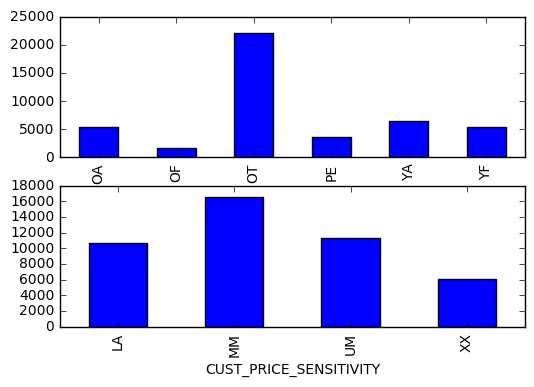

```python
import matplotlib.pyplot as plt  #http://pandas.pydata.org/pandas-docs/stable/visualization.html
%matplotlib inline

plt.figure()

#http://pbpython.com/simple-graphing-pandas.html

plt.subplot(211)
lsPlot = data_cross.groupby(['CUST_LIFESTAGE'])['SPEND'].count().plot(kind='bar')
plt.subplot(212)
psPlot = data_cross.groupby(['CUST_PRICE_SENSITIVITY'])['SPEND'].count().plot(kind='bar')
```

# Split the data.

```python
#create the training, testing split.  can't use sklearn.cross_validation.train_test_split since I have two targets
# could probably consider stratified sampling here

#first do a 70-30 split.
train_X=data_cross.sample(frac=0.7,random_state=42)
test_X=data_cross.drop(train_X.index)

#pop off the classifiers
train_y = train_X[["CUST_LIFESTAGE","CUST_PRICE_SENSITIVITY"]] #potentially for use in multi-output decision trees
train_y_LS = train_X.pop("CUST_LIFESTAGE")
train_y_PS = train_X.pop("CUST_PRICE_SENSITIVITY")

test_y = test_X[["CUST_LIFESTAGE","CUST_PRICE_SENSITIVITY"]] #potentially for use in multi-output decision trees
test_y_LS = test_X.pop("CUST_LIFESTAGE")
test_y_PS = test_X.pop("CUST_PRICE_SENSITIVITY")
```

# Downsample the training so all strata are equal

```python
#based on  https://www.datarobot.com/blog/classification-with-scikit-learn/

rng = np.random.RandomState(42)

#create a copy:
data_cross_for_balanced_PS = data_cross
data_cross_for_balanced_LS = data_cross

#first do a 70-30 split.
balanced_PS_train_X=data_cross_for_balanced_PS.sample(frac=0.7,random_state=42)
balanced_PS_test_X=data_cross_for_balanced_PS.drop(balanced_PS_train_X.index)

#downsample the training data
print(balanced_PS_train_X.groupby(['CUST_PRICE_SENSITIVITY'])['SPEND'].count())
min_count_PS = min(balanced_PS_train_X.groupby(['CUST_PRICE_SENSITIVITY'])['SPEND'].count())
print (min_count_PS)
indices_LA = np.where(balanced_PS_train_X.CUST_PRICE_SENSITIVITY == 'LA')[0]
rng.shuffle(indices_LA)
balanced_PS_train_X = balanced_PS_train_X.drop(balanced_PS_train_X.index[indices_LA[min_count_PS:]])

indices_MM = np.where(balanced_PS_train_X.CUST_PRICE_SENSITIVITY == 'MM')[0]
rng.shuffle(indices_MM)
balanced_PS_train_X = balanced_PS_train_X.drop(balanced_PS_train_X.index[indices_MM[min_count_PS:]])

indices_UM = np.where(balanced_PS_train_X.CUST_PRICE_SENSITIVITY == 'UM')[0]
rng.shuffle(indices_UM)
balanced_PS_train_X = balanced_PS_train_X.drop(balanced_PS_train_X.index[indices_UM[min_count_PS:]])

indices_XX = np.where(balanced_PS_train_X.CUST_PRICE_SENSITIVITY == 'XX')[0]
rng.shuffle(indices_XX)
balanced_PS_train_X = balanced_PS_train_X.drop(balanced_PS_train_X.index[indices_XX[min_count_PS:]])

print('After downsampling', balanced_PS_train_X.groupby(['CUST_PRICE_SENSITIVITY'])['SPEND'].count())

#pop off the classifiers
balanced_PS_train_y_LS = balanced_PS_train_X.pop("CUST_LIFESTAGE") #don't need this
balanced_PS_train_y_PS = balanced_PS_train_X.pop("CUST_PRICE_SENSITIVITY")

balanced_PS_test_y_LS = balanced_PS_test_X.pop("CUST_LIFESTAGE") #don't need this
balanced_PS_test_y_PS = balanced_PS_test_X.pop("CUST_PRICE_SENSITIVITY")



#first do a 70-30 split.
balanced_LS_train_X=data_cross_for_balanced_LS.sample(frac=0.7,random_state=42)
balanced_LS_test_X=data_cross_for_balanced_LS.drop(balanced_LS_train_X.index)

#downsample the training data
print(balanced_LS_train_X.groupby(['CUST_LIFESTAGE'])['SPEND'].count())
min_count_LS = min(balanced_LS_train_X.groupby(['CUST_LIFESTAGE'])['SPEND'].count())

indices_OA = np.where(balanced_LS_train_X.CUST_LIFESTAGE == 'OA')[0]
rng.shuffle(indices_OA)
balanced_LS_train_X = balanced_LS_train_X.drop(balanced_LS_train_X.index[indices_OA[min_count_LS:]])

indices_OF = np.where(balanced_LS_train_X.CUST_LIFESTAGE == 'OF')[0]
rng.shuffle(indices_OF)
balanced_LS_train_X = balanced_LS_train_X.drop(balanced_LS_train_X.index[indices_OF[min_count_LS:]])

indices_OT = np.where(balanced_LS_train_X.CUST_LIFESTAGE == 'OT')[0]
rng.shuffle(indices_OT)
balanced_LS_train_X = balanced_LS_train_X.drop(balanced_LS_train_X.index[indices_OT[min_count_LS:]])

indices_PE = np.where(balanced_LS_train_X.CUST_LIFESTAGE == 'PE')[0]
rng.shuffle(indices_PE)
balanced_LS_train_X = balanced_LS_train_X.drop(balanced_LS_train_X.index[indices_PE[min_count_LS:]])

indices_YA = np.where(balanced_LS_train_X.CUST_LIFESTAGE == 'YA')[0]
rng.shuffle(indices_YA)
balanced_LS_train_X = balanced_LS_train_X.drop(balanced_LS_train_X.index[indices_YA[min_count_LS:]])

indices_YF = np.where(balanced_LS_train_X.CUST_LIFESTAGE == 'YF')[0]
rng.shuffle(indices_YF)
balanced_LS_train_X = balanced_LS_train_X.drop(balanced_LS_train_X.index[indices_YF[min_count_LS:]])

print('After downsampling',balanced_LS_train_X.groupby(['CUST_LIFESTAGE'])['SPEND'].count())

#pop off the classifiers
balanced_LS_train_y_LS = balanced_LS_train_X.pop("CUST_LIFESTAGE")
balanced_LS_train_y_PS = balanced_LS_train_X.pop("CUST_PRICE_SENSITIVITY") #don't need this

balanced_LS_test_y_LS = balanced_LS_test_X.pop("CUST_LIFESTAGE")
balanced_LS_test_y_PS = balanced_LS_test_X.pop("CUST_PRICE_SENSITIVITY") #don't need this
```

```
CUST_PRICE_SENSITIVITY
LA     7467
MM    11628
UM     7936
XX     4223
Name: SPEND, dtype: int64
4223
('After downsampling', CUST_PRICE_SENSITIVITY
LA    4223
MM    4223
UM    4223
XX    4223
Name: SPEND, dtype: int64)
CUST_LIFESTAGE
OA     3723
OF     1255
OT    15496
PE     2503
YA     4469
YF     3808
Name: SPEND, dtype: int64
('After downsampling', CUST_LIFESTAGE
OA    1255
OF    1255
OT    1255
PE    1255
YA    1255
YF    1255
Name: SPEND, dtype: int64)
```

# Upsample the training so all strata are equal

```python
#upsampling for PS, per http://www.site.uottawa.ca/~nat/Courses/csi5388/Class-Imbalances.ppt
from sklearn.utils import resample
data_cross_upsampled_PS = data_cross

#first do a 70-30 split.
upsampled_PS_train_X=data_cross_upsampled_PS.sample(frac=0.7,random_state=42)
upsampled_PS_test_X=data_cross_upsampled_PS.drop(upsampled_PS_train_X.index)

print(upsampled_PS_train_X.groupby(['CUST_PRICE_SENSITIVITY'])['SPEND'].count())
max_count_PS = max(upsampled_PS_train_X.groupby(['CUST_PRICE_SENSITIVITY'])['SPEND'].count())

subset_LA = upsampled_PS_train_X[upsampled_PS_train_X.CUST_PRICE_SENSITIVITY == 'LA']
up_subset_LA = resample(subset_LA, n_samples=max_count_PS-len(subset_LA))
subset_MM = upsampled_PS_train_X[upsampled_PS_train_X.CUST_PRICE_SENSITIVITY == 'MM']
up_subset_MM = resample(subset_MM, n_samples=max_count_PS-len(subset_MM))
subset_UM = upsampled_PS_train_X[upsampled_PS_train_X.CUST_PRICE_SENSITIVITY == 'UM']
up_subset_UM = resample(subset_UM, n_samples=max_count_PS-len(subset_UM))
subset_XX = upsampled_PS_train_X[upsampled_PS_train_X.CUST_PRICE_SENSITIVITY == 'XX']
up_subset_XX = resample(subset_XX, n_samples=max_count_PS-len(subset_XX))

upsampled_PS_train_X = pd.concat([subset_LA,up_subset_LA, subset_UM, up_subset_UM,
                                     subset_MM, up_subset_MM, subset_XX, up_subset_XX])

print(upsampled_PS_train_X.groupby(['CUST_PRICE_SENSITIVITY'])['SPEND'].count())


#pop off the classifiers
upsampled_PS_train_y_LS = upsampled_PS_train_X.pop("CUST_LIFESTAGE") #don't need this
upsampled_PS_train_y_PS = upsampled_PS_train_X.pop("CUST_PRICE_SENSITIVITY")
upsampled_PS_test_y_LS = upsampled_PS_test_X.pop("CUST_LIFESTAGE") #don't need this
upsampled_PS_test_y_PS = upsampled_PS_test_X.pop("CUST_PRICE_SENSITIVITY")

#upsampling for LS
data_cross_upsampled_LS = data_cross

#first do a 70-30 split.
upsampled_LS_train_X=data_cross_upsampled_LS.sample(frac=0.7,random_state=42)
upsampled_LS_test_X=data_cross_upsampled_LS.drop(upsampled_LS_train_X.index)

#upsample the training data

print(upsampled_LS_train_X.groupby(['CUST_LIFESTAGE'])['SPEND'].count())
max_count_LS = max(upsampled_LS_train_X.groupby(['CUST_LIFESTAGE'])['SPEND'].count())

subset_OA = upsampled_LS_train_X[upsampled_LS_train_X.CUST_LIFESTAGE == 'OA']
up_subset_OA = resample(subset_OA, n_samples=max_count_LS-len(subset_OA))
subset_OT = upsampled_LS_train_X[upsampled_LS_train_X.CUST_LIFESTAGE == 'OT']
up_subset_OT = resample(subset_OT, n_samples=max_count_LS-len(subset_OT))
subset_PE = upsampled_LS_train_X[upsampled_LS_train_X.CUST_LIFESTAGE == 'PE']
up_subset_PE = resample(subset_PE, n_samples=max_count_LS-len(subset_PE))
subset_YA = upsampled_LS_train_X[upsampled_LS_train_X.CUST_LIFESTAGE == 'YA']
up_subset_YA = resample(subset_YA, n_samples=max_count_LS-len(subset_YA))
subset_OF = upsampled_LS_train_X[upsampled_LS_train_X.CUST_LIFESTAGE == 'OF']
up_subset_OF = resample(subset_OF, n_samples=max_count_LS-len(subset_OF))
subset_YF = upsampled_LS_train_X[upsampled_LS_train_X.CUST_LIFESTAGE == 'YF']
up_subset_YF = resample(subset_YF, n_samples=max_count_LS-len(subset_YF))

upsampled_LS_train_X = pd.concat([up_subset_OA,up_subset_OF, up_subset_YA, up_subset_YF, up_subset_PE, up_subset_OT,
                                     subset_OA, subset_OF, subset_YA, subset_YF, subset_PE, subset_OT ])

print(upsampled_LS_train_X.groupby(['CUST_LIFESTAGE'])['SPEND'].count())

#pop off the classifiers
upsampled_LS_train_y_LS = upsampled_LS_train_X.pop("CUST_LIFESTAGE")
upsampled_LS_train_y_PS = upsampled_LS_train_X.pop("CUST_PRICE_SENSITIVITY") #don't need this

upsampled_LS_test_y_LS = upsampled_LS_test_X.pop("CUST_LIFESTAGE")
upsampled_LS_test_y_PS = upsampled_LS_test_X.pop("CUST_PRICE_SENSITIVITY") #don't need this
```

```
CUST_PRICE_SENSITIVITY
LA     7467
MM    11628
UM     7936
XX     4223
Name: SPEND, dtype: int64
CUST_PRICE_SENSITIVITY
LA    11628
MM    11628
UM    11628
XX    11628
Name: SPEND, dtype: int64
CUST_LIFESTAGE
OA     3723
OF     1255
OT    15496
PE     2503
YA     4469
YF     3808
Name: SPEND, dtype: int64
CUST_LIFESTAGE
OA    15496
OF    15496
OT    15496
PE    15496
YA    15496
YF    15496
Name: SPEND, dtype: int64
```

# Create some helper functions

```python
from sklearn.metrics import confusion_matrix

#Create a function to test classifiers and create simple output
def tryClassifier_PS (title,psClassifier, train_X, test_X, train_y_PS, test_y_PS):
    ps_pred_train = psClassifier.predict(train_X)
    ps_pred_test = psClassifier.predict(test_X)

    print(title)
    print('Price Sensitivity Training: ', psClassifier.score(train_X, train_y_PS))
    print(confusion_matrix(train_y_PS, ps_pred_train, labels=["LA", "MM", "UM","XX"]))
    print('Price Sensitivity Testing: ', psClassifier.score(test_X, test_y_PS))
    print(confusion_matrix(test_y_PS, ps_pred_test, labels=["LA", "MM", "UM","XX"]))


def tryClassifier_LS (title, lsClassifier, train_X, test_X, train_y_LS, test_y_LS):

    ls_pred_train = lsClassifier.predict(train_X)
    ls_pred_test = lsClassifier.predict(test_X)

    print(title)
    print('LifeStage Training: ', lsClassifier.score(train_X, train_y_LS))
    print(confusion_matrix(train_y_LS, ls_pred_train, labels=["OA", "OF", "OT","PE","YA","YF"]))
    print('LifeStage Testing: ', lsClassifier.score(test_X, test_y_LS))
    print(confusion_matrix(test_y_LS, ls_pred_test, labels=["OA", "OF", "OT","PE","YA","YF"]))


def tryClassifier_LS_OT (title, lsClassifier, train_X, test_X, train_y_LS, test_y_LS):

    ls_pred_train = lsClassifier.predict(train_X)
    ls_pred_test = lsClassifier.predict(test_X)
    print(title)
    print('LifeStage Training: ', lsClassifier.score(train_X, train_y_LS))
    print(confusion_matrix(train_y_LS, ls_pred_train, labels=["LS", "OT"]))
    print('LifeStage Testing: ', lsClassifier.score(test_X, test_y_LS))
    print(confusion_matrix(test_y_LS, ls_pred_test, labels=["LS", "OT"]))


from sklearn.metrics import accuracy_score

#create an accuracy metric
def performance_metric(y_true, y_predict):
    """ Calculates and returns the performance score between
        true and predicted values based on the metric chosen. """

    # TODO: Calculate the performance score between 'y_true' and 'y_predict'
    score = accuracy_score(y_true, y_predict)

    # Return the score
    return score
from sklearn.metrics import make_scorer
scoring_fnc = make_scorer(performance_metric)
```

# try the classifiers

```python
from sklearn.ensemble import RandomForestClassifier #using scikitlearn 0.17.1


rfc_ps = RandomForestClassifier(n_estimators = 10000,random_state=42, criterion="entropy"
                                , max_features = 10
                                #, max_leaf_nodes=1000
                                #, min_samples_leaf=20
                                , oob_score=True
                               )
rfc_ls = RandomForestClassifier(n_estimators = 10000,random_state=42, criterion="entropy"
                                , max_features = 10
                                #, max_leaf_nodes=1000
                                #, min_samples_leaf=20
                                , oob_score=True
                               )
#need to handle categorical variables either through pandas.getDummies or http://scikit-learn.org/dev/modules/generated/sklearn.preprocessing.OneHotEncoder.html#sklearn.preprocessing.OneHotEncoder
#train_X_num

#print(train_X_dummied.head(10))
#print(list(train_X_dummied.columns.values))

print ('Recall that running training data back through the random forest is not as good an indicator of performance as the OOB score')

print('Unbalanced:')
rfc_ps = rfc_ps.fit(train_X, train_y_PS)

print('Price Sensitivity OOB: ', rfc_ps.oob_score_)
tryClassifier_PS ("Random Forest",rfc_ps, train_X, test_X, train_y_PS, test_y_PS)

rfc_ls = rfc_ls.fit(train_X, train_y_LS)

print('Life Stage OOB: ', rfc_ls.oob_score_)
tryClassifier_LS ("Random Forest", rfc_ls, train_X, test_X, train_y_LS, test_y_LS)



rfc_balanced_ps = RandomForestClassifier(n_estimators = 10000,random_state=42, criterion="entropy"
                                , max_features = 10
                                #, max_leaf_nodes=1000
                                #, min_samples_leaf=20
                                , oob_score=True
                               )
rfc_balanced_ls = RandomForestClassifier(n_estimators = 10000,random_state=42, criterion="entropy"
                                , max_features = 10
                                #, max_leaf_nodes=1000
                                #, min_samples_leaf=20
                                , oob_score=True
                               )
#need to handle categorical variables either through pandas.getDummies or http://scikit-learn.org/dev/modules/generated/sklearn.preprocessing.OneHotEncoder.html#sklearn.preprocessing.OneHotEncoder
#train_X_num

#print(train_X_dummied.head(10))
#print(list(train_X_dummied.columns.values))
print('Downsampled:')
rfc_balanced_ps = rfc_balanced_ps.fit(balanced_PS_train_X, balanced_PS_train_y_PS)

print('Price Sensitivity OOB: ', rfc_ps.oob_score_)
tryClassifier_PS ("Random Forest",rfc_balanced_ps, balanced_PS_train_X, test_X, balanced_PS_train_y_PS, test_y_PS)

rfc_balanced_ls = rfc_balanced_ls.fit(balanced_LS_train_X, balanced_LS_train_y_LS)

print('Life Stage OOB: ', rfc_ls.oob_score_)
tryClassifier_LS ("Random Forest", rfc_balanced_ls, balanced_LS_train_X, test_X, balanced_LS_train_y_LS, test_y_LS)
```

```
Recall that running training data back through the random forest is not as good an indicator of performance as the OOB score
Unbalanced:
('Price Sensitivity OOB: ', 0.61726499008126956)
Random Forest
('Price Sensitivity Training: ', 1.0)
[[ 7467     0     0     0]
 [    0 11628     0     0]
 [    0     0  7936     0]
 [    0     0     0  4223]]
('Price Sensitivity Testing: ', 0.62291899962672637)
[[1141 1915  106   60]
 [ 435 3845  596   99]
 [  37 1650 1613   54]
 [  24   70    5 1745]]
('Life Stage OOB: ', 0.52252511678505154)
('LifeStage Training: ', 0.99993600819095152)
[[ 3723     0     0     0     0     0]
 [    0  1255     0     0     0     0]
 [    0     0 15496     0     0     0]
 [    0     0     0  2503     0     0]
 [    0     0     2     0  4467     0]
 [    0     0     0     0     0  3808]]
('LifeStage Testing: ', 0.51765584173198953)
[[  67    0 1421   81    2   65]
 [   2    0  366    0    0  133]
 [  52    0 6159   99   21  299]
 [  65    0  802  223    0    7]
 [  27    0 1689   23   26  141]
 [   7    0 1146    8    5  459]]
Downsampled:
('Price Sensitivity OOB: ', 0.61726499008126956)
Random Forest
('Price Sensitivity Training: ', 1.0)
[[4223    0    0    0]
 [   0 4223    0    0]
 [   0    0 4223    0]
 [   0    0    0 4223]]
('Price Sensitivity Testing: ', 0.59245987308697279)
[[2170  576  377   99]
 [1713 1640 1464  158]
 [ 363  551 2347   93]
 [  34    7   24 1779]]
('Life Stage OOB: ', 0.52252511678505154)
('LifeStage Training: ', 1.0)
[[1255    0    0    0    0    0]
 [   0 1255    0    0    0    0]
 [   0    0 1255    0    0    0]
 [   0    0    0 1255    0    0]
 [   0    0    0    0 1255    0]
 [   0    0    0    0    0 1255]]
('LifeStage Testing: ', 0.43135498320268756)
[[ 337  163  158  559  298  121]
 [  29  108   62   37  112  153]
 [ 382  481 3142  901 1250  474]
 [ 134   20  158  724   46   15]
 [ 210  217  210  200  832  237]
 [ 105  281  175  134  295  635]]
```

## Sample Output Recall that running training data back through the random forest is not as good an indicator of performance as the OOB score Unbalanced: ('Price Sensitivity OOB: ', 0.61726499008126956) Random Forest ('Price Sensitivity Training: ', 1.0) [[ 7467 0 0 0] [ 0 11628 0 0] [ 0 0 7936 0] [ 0 0 0 4223]] ('Price Sensitivity Testing: ', 0.62291899962672637) [[1141 1915 106 60] [ 435 3845 596 99] [ 37 1650 1613 54] [ 24 70 5 1745]] ('Life Stage OOB: ', 0.52252511678505154) ('LifeStage Training: ', 0.99993600819095152) [[ 3723 0 0 0 0 0] [ 0 1255 0 0 0 0] [ 0 0 15496 0 0 0] [ 0 0 0 2503 0 0] [ 0 0 2 0 4467 0] [ 0 0 0 0 0 3808]] ('LifeStage Testing: ', 0.51765584173198953) [[ 67 0 1421 81 2 65] [ 2 0 366 0 0 133] [ 52 0 6159 99 21 299] [ 65 0 802 223 0 7] [ 27 0 1689 23 26 141] [ 7 0 1146 8 5 459]] Downsampled: ('Price Sensitivity OOB: ', 0.61726499008126956) Random Forest ('Price Sensitivity Training: ', 1.0) [[4223 0 0 0] [ 0 4223 0 0] [ 0 0 4223 0] [ 0 0 0 4223]] ('Price Sensitivity Testing: ', 0.59245987308697279) [[2170 576 377 99] [1713 1640 1464 158] [ 363 551 2347 93] [ 34 7 24 1779]] ('Life Stage OOB: ', 0.52252511678505154) ('LifeStage Training: ', 1.0) [[1255 0 0 0 0 0] [ 0 1255 0 0 0 0] [ 0 0 1255 0 0 0] [ 0 0 0 1255 0 0] [ 0 0 0 0 1255 0] [ 0 0 0 0 0 1255]] ('LifeStage Testing: ', 0.43135498320268756) [[ 337 163 158 559 298 121] [ 29 108 62 37 112 153] [ 382 481 3142 901 1250 474] [ 134 20 158 724 46 15] [ 210 217 210 200 832 237] [ 105 281 175 134 295 635]]

```python
from sklearn.ensemble import RandomForestClassifier #using scikitlearn 0.17.1

rfc_upsampled_ps = RandomForestClassifier(n_estimators = 1000,random_state=42, criterion="entropy"
                                , max_features = 10
                                #, max_leaf_nodes=1000
                                #, min_samples_leaf=20
                                , oob_score=True
                               )
print('Upsampled:')

rfc_upsampled_ps = rfc_upsampled_ps.fit(upsampled_PS_train_X, upsampled_PS_train_y_PS)

print('Price Sensitivity OOB: ', rfc_upsampled_ps.oob_score_)
tryClassifier_PS ("Random Forest", rfc_upsampled_ps, upsampled_PS_train_X, test_X, upsampled_PS_train_y_PS, test_y_PS)


rfc_upsampled_ls = RandomForestClassifier(n_estimators = 1000,random_state=42, criterion="entropy"
                                , max_features = 10
                                #, max_leaf_nodes=1000
                                #, min_samples_leaf=20
                                , oob_score=True
                               )

rfc_upsampled_ls = rfc_upsampled_ls.fit(upsampled_LS_train_X, upsampled_LS_train_y_LS)

print('Life Stage OOB: ', rfc_upsampled_ls.oob_score_)
tryClassifier_LS ("Random Forest", rfc_upsampled_ls, upsampled_LS_train_X, test_X, upsampled_LS_train_y_LS, test_y_LS)
```

```
Upsampled:
('Price Sensitivity OOB: ', 0.81215600275197797)
Random Forest
('Price Sensitivity Training: ', 1.0)
[[11628     0     0     0]
 [    0 11628     0     0]
 [    0     0 11628     0]
 [    0     0     0 11628]]
('Price Sensitivity Testing: ', 0.6276969018290407)
[[1520 1444  188   70]
 [ 764 3234  863  114]
 [ 115 1281 1891   67]
 [  26   38   17 1763]]
('Life Stage OOB: ', 0.95836559972466018)
('LifeStage Training: ', 0.9999784890724488)
[[15496     0     0     0     0     0]
 [    0 15496     0     0     0     0]
 [    0     0 15494     0     2     0]
 [    0     0     0 15496     0     0]
 [    0     0     0     0 15496     0]
 [    0     0     0     0     0 15496]]
('LifeStage Testing: ', 0.51653602090332218)
[[ 273    0  921  168  114  160]
 [  17    0  247    2   54  181]
 [ 228    0 5139  220  491  552]
 [ 171    0  519  379    9   19]
 [ 108    0 1046   40  441  271]
 [  56    0  728   16  138  687]]
```

## sample output Upsampled: ('Price Sensitivity OOB: ', 0.81215600275197797) Random Forest ('Price Sensitivity Training: ', 1.0) [[11628 0 0 0] [ 0 11628 0 0] [ 0 0 11628 0] [ 0 0 0 11628]] ('Price Sensitivity Testing: ', 0.6276969018290407) [[1520 1444 188 70] [ 764 3234 863 114] [ 115 1281 1891 67] [ 26 38 17 1763]] ('Life Stage OOB: ', 0.95836559972466018) ('LifeStage Training: ', 0.9999784890724488) [[15496 0 0 0 0 0] [ 0 15496 0 0 0 0] [ 0 0 15494 0 2 0] [ 0 0 0 15496 0 0] [ 0 0 0 0 15496 0] [ 0 0 0 0 0 15496]] ('LifeStage Testing: ', 0.51653602090332218) [[ 273 0 921 168 114 160] [ 17 0 247 2 54 181] [ 228 0 5139 220 491 552] [ 171 0 519 379 9 19] [ 108 0 1046 40 441 271] [ 56 0 728 16 138 687]]

```python
#try a two-stage LS
#step 1, predict OT or not
#step 2, for those we predict !OT then predict the rest.

#get the training data, excluding OTs


train_y_LS_excOT = train_y_LS[train_y_LS<> 'OT']
train_X_excOT = train_X[train_y_LS<> 'OT']

#create a second training set where anything other than 'OT' is labelled 'LS'

train_y_LS_BinaryOT = train_y_LS.copy()
train_y_LS_BinaryOT [train_y_LS_BinaryOT<> 'OT'] = 'LS'

test_y_LS_BinaryOT = test_y_LS.copy()
test_y_LS_BinaryOT [test_y_LS_BinaryOT<> 'OT'] = 'LS'


from sklearn.ensemble import RandomForestClassifier #using scikitlearn 0.17.1

#step 1, create a model that clasiffies as LS or not.
rfc_twostage_ls = RandomForestClassifier(n_estimators = 10000, random_state=42, criterion="entropy"
                                , max_features = 10
                                #, max_leaf_nodes=1000
                                #, min_samples_leaf=20
                                , oob_score=True
                               )
print('twostage step 1:')

rfc_twostage_ls = rfc_twostage_ls.fit(train_X, train_y_LS_BinaryOT)

print('Price Sensitivity OOB: ', rfc_twostage_ls.oob_score_)
tryClassifier_LS_OT ("Random Forest", rfc_twostage_ls, train_X, test_X, train_y_LS_BinaryOT, test_y_LS_BinaryOT)

#get the stage 1 predictions
rfc_twostage_ls_preds = rfc_twostage_ls.predict(test_X)

#print(rfc_twostage_ls.feature_importances_ )

#step 2, using the training data that excludes OT, predict the other classes
from sklearn.metrics import accuracy_score
#fit a model on training data that isn't OT
rfc_twostage_ls_2 = RandomForestClassifier(n_estimators = 1000, random_state=42, criterion="entropy"
                                , max_features = 20
                                , max_leaf_nodes=1000
                                , min_samples_leaf=20
                                , oob_score=True
                               )

print('twostage step 2:')
rfc_twostage_ls_2 = rfc_twostage_ls_2.fit(train_X_excOT,train_y_LS_excOT)

#get the test values where we predict LS instead of 'OT'
stage1_LS_test_X = test_X[rfc_twostage_ls_preds=='LS']
stage1_LS_test_y_LS = test_y_LS[rfc_twostage_ls_preds=='LS']
stage1_LS_test_y_OT = test_y_LS[rfc_twostage_ls_preds=='OT']

#construct a new set of Ys and Predictions to evaluate
rfc_twostage_ls_2_preds = rfc_twostage_ls_2.predict(stage1_LS_test_X)
rfc_twostage_ls_OT_preds = rfc_twostage_ls_preds[rfc_twostage_ls_preds=='OT']

constructedY = pd.concat([stage1_LS_test_y_OT,stage1_LS_test_y_LS])
constructedPreds = pd.concat([pd.DataFrame(rfc_twostage_ls_OT_preds), pd.DataFrame(rfc_twostage_ls_2_preds)])

print(confusion_matrix(test_y_LS_BinaryOT, rfc_twostage_ls_preds, labels=["LS", "OT"]))
print('Price Sensitivity OOB: ', rfc_twostage_ls_2.oob_score_)

print(confusion_matrix(stage1_LS_test_y_LS, rfc_twostage_ls_2_preds, labels=["OA", "OF","PE","YA","YF","OT"]))
print(accuracy_score(stage1_LS_test_y_LS,rfc_twostage_ls_2_preds))
print(confusion_matrix(constructedY, constructedPreds, labels=["OA", "OF", "OT","PE","YA","YF"]))
print(accuracy_score(constructedY,constructedPreds))
```

[output not shown]

```
twostage step 1:
('Price Sensitivity OOB: ', 0.70023037051257442)
('LifeStage Training: ', 0.99993600819095152)
[[15756     2]
 [    0 15496]]
('LifeStage Testing: ', 0.6935423665546846)
[[5612 1153]
 [2952 3678]]
```

```python
from sklearn.ensemble import GradientBoostingClassifier
gbc_ps = GradientBoostingClassifier(learning_rate=0.05, n_estimators=1000, max_depth=10)
balanced_gbc_ps = GradientBoostingClassifier(learning_rate=0.05, n_estimators=1000, max_depth=10)
upsampled_gbc_ps = GradientBoostingClassifier(learning_rate=0.05, n_estimators=1000, max_depth=10)

#gbc_ls = GradientBoostingClassifier(learning_rate=0.05, n_estimators=1000, max_depth=10)

gbc_ps = gbc_ps.fit(train_X, train_y_PS)
balanced_gbc_ps = balanced_gbc_ps.fit(balanced_PS_train_X, balanced_PS_train_y_PS)
upsampled_gbc_ps = upsampled_gbc_ps.fit(upsampled_PS_train_X, upsampled_PS_train_y_PS)
#gbc_ls = rfc_ls.fit(train_X, train_y_LS)

tryClassifier_PS ("Gradient Boosting Classifier, reg",gbc_ps, train_X, test_X, train_y_PS, test_y_PS)
tryClassifier_PS ("Gradient Boosting Classifier, downsampled",balanced_gbc_ps, balanced_PS_train_X, test_X, balanced_PS_train_y_PS, test_y_PS)
tryClassifier_PS ("Gradient Boosting Classifier, upsampled",upsampled_gbc_ps, upsampled_PS_train_X, test_X, upsampled_PS_train_y_PS, test_y_PS)
```

```
Gradient Boosting Classifier, reg
('Price Sensitivity Training: ', 1.0)
[[ 7467     0     0     0]
 [    0 11628     0     0]
 [    0     0  7936     0]
 [    0     0     0  4223]]
('Price Sensitivity Testing: ', 0.62732362821948484)
[[1491 1552  146   33]
 [ 718 3376  828   53]
 [ 116 1371 1838   29]
 [  34   71   41 1698]]
Gradient Boosting Classifier, downsampled
('Price Sensitivity Training: ', 1.0)
[[4223    0    0    0]
 [   0 4223    0    0]
 [   0    0 4223    0]
 [   0    0    0 4223]]
('Price Sensitivity Testing: ', 0.60126913027248974)
[[2007  839  314   62]
 [1457 2053 1361  104]
 [ 288  772 2235   59]
 [  35   19   31 1759]]
Gradient Boosting Classifier, upsampled
('Price Sensitivity Training: ', 1.0)
[[11628     0     0     0]
 [    0 11628     0     0]
 [    0     0 11628     0]
 [    0     0     0 11628]]
('Price Sensitivity Testing: ', 0.62164986935423661)
[[1523 1500  164   35]
 [ 807 3195  920   53]
 [ 128 1308 1887   31]
 [  30   62   30 1722]]
```

## sample output Gradient Boosting Classifier, reg ('Price Sensitivity Training: ', 1.0) [[ 7467 0 0 0] [ 0 11628 0 0] [ 0 0 7936 0] [ 0 0 0 4223]] ('Price Sensitivity Testing: ', 0.62732362821948484) [[1491 1552 146 33] [ 718 3376 828 53] [ 116 1371 1838 29] [ 34 71 41 1698]] Gradient Boosting Classifier, downsampled ('Price Sensitivity Training: ', 1.0) [[4223 0 0 0] [ 0 4223 0 0] [ 0 0 4223 0] [ 0 0 0 4223]] ('Price Sensitivity Testing: ', 0.60126913027248974) [[2007 839 314 62] [1457 2053 1361 104] [ 288 772 2235 59] [ 35 19 31 1759]] Gradient Boosting Classifier, upsampled ('Price Sensitivity Training: ', 1.0) [[11628 0 0 0] [ 0 11628 0 0] [ 0 0 11628 0] [ 0 0 0 11628]] ('Price Sensitivity Testing: ', 0.62164986935423661) [[1523 1500 164 35] [ 807 3195 920 53] [ 128 1308 1887 31] [ 30 62 30 1722]]

```python
from sklearn.ensemble import GradientBoostingClassifier
gbc_LS = GradientBoostingClassifier(learning_rate=0.05, n_estimators=1000, max_depth=10)
balanced_gbc_LS = GradientBoostingClassifier(learning_rate=0.05, n_estimators=1000, max_depth=10)
upsampled_gbc_LS=GradientBoostingClassifier(learning_rate=0.05, n_estimators=1000, max_depth=10)
#gbc_ls = GradientBoostingClassifier(learning_rate=0.05, n_estimators=1000, max_depth=10)

gbc_LS = gbc_LS.fit(train_X, train_y_LS)
balanced_gbc_LS = balanced_gbc_LS.fit(balanced_LS_train_X, balanced_LS_train_y_LS)
upsampled_gbc_LS = upsampled_gbc_LS.fit(upsampled_LS_train_X, upsampled_LS_train_y_LS)


tryClassifier_LS ("Gradient Boosting Classifier, reg",gbc_LS, train_X, test_X, train_y_LS, test_y_LS)
tryClassifier_LS ("Gradient Boosting Classifier, downsampled" ,balanced_gbc_LS, balanced_LS_train_X, test_X, balanced_LS_train_y_LS, test_y_LS)
tryClassifier_LS ("Gradient Boosting Classifier, upsampled" ,upsampled_gbc_LS, upsampled_LS_train_X, test_X, upsampled_LS_train_y_LS, test_y_LS)
```

```
('LifeStage Training: ', 0.99993600819095152)
[[ 3723     0     0     0     0     0]
 [    0  1255     0     0     0     0]
 [    0     0 15496     0     0     0]
 [    0     0     0  2503     0     0]
 [    0     0     2     0  4467     0]
 [    0     0     0     0     0  3808]]
('LifeStage Testing: ', 0.51399776035834266)
[[ 149    0 1317   75   47   48]
 [   7    7  386    0   13   88]
 [ 112    4 5950  136  169  259]
 [ 106    0  743  231   10    7]
 [  53    1 1571   22  152  107]
 [  27    3 1124   12   63  396]]
('LifeStage Training: ', 1.0)
[[1255    0    0    0    0    0]
 [   0 1255    0    0    0    0]
 [   0    0 1255    0    0    0]
 [   0    0    0 1255    0    0]
 [   0    0    0    0 1255    0]
 [   0    0    0    0    0 1255]]
('LifeStage Testing: ', 0.41306457633445315)
[[ 413  185  199  430  268  141]
 [  54  131   50   19   94  153]
 [ 670  587 2986  719 1022  646]
 [ 212   31  143  647   44   20]
 [ 288  253  235  132  691  307]
 [ 149  328  154   77  252  665]]
('LifeStage Training: ', 0.9999784890724488)
[[15496     0     0     0     0     0]
 [    0 15496     0     0     0     0]
 [    0     0 15495     0     1     0]
 [    0     0     0 15496     0     0]
 [    0     0     1     0 15495     0]
 [    0     0     0     0     0 15496]]
('LifeStage Testing: ', 0.51773049645390068)
[[ 235    0 1118  104  116   63]
 [  13    0  325    1   36  126]
 [ 210    3 5557  166  367  327]
 [ 164    0  603  310   10   10]
 [  91    0 1286   26  351  152]
 [  46    2  948   12  135  482]]
```

## sample output ('LifeStage Training: ', 0.99993600819095152) [[ 3723 0 0 0 0 0] [ 0 1255 0 0 0 0] [ 0 0 15496 0 0 0] [ 0 0 0 2503 0 0] [ 0 0 2 0 4467 0] [ 0 0 0 0 0 3808]] ('LifeStage Testing: ', 0.51399776035834266) [[ 149 0 1317 75 47 48] [ 7 7 386 0 13 88] [ 112 4 5950 136 169 259] [ 106 0 743 231 10 7] [ 53 1 1571 22 152 107] [ 27 3 1124 12 63 396]] ('LifeStage Training: ', 1.0) [[1255 0 0 0 0 0] [ 0 1255 0 0 0 0] [ 0 0 1255 0 0 0] [ 0 0 0 1255 0 0] [ 0 0 0 0 1255 0] [ 0 0 0 0 0 1255]] ('LifeStage Testing: ', 0.41306457633445315) [[ 413 185 199 430 268 141] [ 54 131 50 19 94 153] [ 670 587 2986 719 1022 646] [ 212 31 143 647 44 20] [ 288 253 235 132 691 307] [ 149 328 154 77 252 665]] ('LifeStage Training: ', 0.9999784890724488) [[15496 0 0 0 0 0] [ 0 15496 0 0 0 0] [ 0 0 15495 0 1 0] [ 0 0 0 15496 0 0] [ 0 0 1 0 15495 0] [ 0 0 0 0 0 15496]] ('LifeStage Testing: ', 0.51773049645390068) [[ 235 0 1118 104 116 63] [ 13 0 325 1 36 126] [ 210 3 5557 166 367 327] [ 164 0 603 310 10 10] [ 91 0 1286 26 351 152] [ 46 2 948 12 135 482]]

```python
from sklearn.neighbors import KNeighborsClassifier

knn_ps = KNeighborsClassifier(n_neighbors=10)
balanced_knn_ps = KNeighborsClassifier(n_neighbors=10)
upsampled_knn_ps = KNeighborsClassifier(n_neighbors=10)

knn_ps = knn_ps.fit(train_X,train_y_PS)
balanced_knn_ps = balanced_knn_ps.fit(balanced_PS_train_X,balanced_PS_train_y_PS)
upsampled_knn_ps = upsampled_knn_ps.fit(upsampled_PS_train_X, upsampled_PS_train_y_PS)

tryClassifier_PS ("KNN Classifier, reg",knn_ps, train_X, test_X, train_y_PS, test_y_PS)
tryClassifier_PS ("KNN Classifier, downsampled",balanced_knn_ps, balanced_PS_train_X, test_X, balanced_PS_train_y_PS, test_y_PS)
tryClassifier_PS ("KNN Classifier, upsampled",upsampled_knn_ps, upsampled_PS_train_X, test_X, upsampled_PS_train_y_PS, test_y_PS)
```

```
KNN Classifier, reg
('Price Sensitivity Training: ', 0.59973123440199649)
[[3675 2971  639  182]
 [2060 8226 1153  189]
 [1107 3673 3000  156]
 [ 123  192   65 3843]]
('Price Sensitivity Testing: ', 0.48294139604329972)
[[1120 1666  343   93]
 [1233 2841  793  108]
 [ 553 1869  861   71]
 [  64   91   42 1647]]
KNN Classifier, downsampled
('Price Sensitivity Training: ', 0.63485673691688371)
[[2598  900  518  207]
 [1258 2096  726  143]
 [ 947 1107 2012  157]
 [  79   61   65 4018]]
('Price Sensitivity Testing: ', 0.46368047779022026)
[[1576  945  509  192]
 [1876 1710 1170  219]
 [ 908 1114 1190  142]
 [  40   35   34 1735]]
KNN Classifier, upsampled
('Price Sensitivity Training: ', 0.67449260405916756)
[[ 8104  1874  1320   330]
 [ 3612  5594  2104   318]
 [ 2239  2587  6485   317]
 [  179   112   148 11189]]
('Price Sensitivity Testing: ', 0.46039567002612913)
[[1571  961  552  138]
 [1944 1682 1183  166]
 [ 889 1127 1224  114]
 [  71   38   45 1690]]
```

## sample output KNN Classifier, reg ('Price Sensitivity Training: ', 0.59973123440199649) [[3675 2971 639 182] [2060 8226 1153 189] [1107 3673 3000 156] [ 123 192 65 3843]] ('Price Sensitivity Testing: ', 0.48294139604329972) [[1120 1666 343 93] [1233 2841 793 108] [ 553 1869 861 71] [ 64 91 42 1647]] KNN Classifier, downsampled ('Price Sensitivity Training: ', 0.63485673691688371) [[2598 900 518 207] [1258 2096 726 143] [ 947 1107 2012 157] [ 79 61 65 4018]] ('Price Sensitivity Testing: ', 0.46368047779022026) [[1576 945 509 192] [1876 1710 1170 219] [ 908 1114 1190 142] [ 40 35 34 1735]] KNN Classifier, upsampled ('Price Sensitivity Training: ', 0.67449260405916756) [[ 8104 1874 1320 330] [ 3612 5594 2104 318] [ 2239 2587 6485 317] [ 179 112 148 11189]] ('Price Sensitivity Testing: ', 0.46039567002612913) [[1571 961 552 138] [1944 1682 1183 166] [ 889 1127 1224 114] [ 71 38 45 1690]]

```python
from sklearn.neighbors import KNeighborsClassifier

knn_LS = KNeighborsClassifier(n_neighbors=10)
balanced_knn_LS = KNeighborsClassifier(n_neighbors=10)
upsampled_knn_LS = KNeighborsClassifier(n_neighbors=10)


knn_LS = knn_LS.fit(train_X,train_y_LS)
balanced_knn_LS = balanced_knn_LS.fit(balanced_LS_train_X,balanced_LS_train_y_LS)
balanced_knn_LS = balanced_knn_LS.fit(upsampled_LS_train_X, upsampled_LS_train_y_LS)

tryClassifier_LS ("KNN Classifier, reg",knn_LS, train_X, test_X, train_y_LS, test_y_LS)
tryClassifier_LS ("KNN Classifier, downsampled",balanced_knn_LS, balanced_LS_train_X, test_X, balanced_LS_train_y_LS, test_y_LS)
tryClassifier_LS ("KNN Classifier, upsampled" ,balanced_knn_LS, upsampled_LS_train_X, test_X, upsampled_LS_train_y_LS, test_y_LS)
```

```
('LifeStage Training: ', 0.5651116657067895)
[[ 1037    31  1879   173   309   294]
 [  107    95   654    10   138   251]
 [  574    70 13453   191   619   589]
 [  350    11  1315   620   111    96]
 [  328    45  2499    72  1159   366]
 [  260    73  1752    55   370  1298]]
('LifeStage Testing: ', 0.46868234415826798)
[[ 228   16  953   98  169  172]
 [  32   16  305    6   51   91]
 [ 362   51 5235  162  429  391]
 [ 197    7  642  149   50   52]
 [ 155   25 1189   46  280  211]
 [ 137   37  877   22  182  370]]
('LifeStage Training: ', 0.68499335989375831)
[[ 843   70   44  112  101   85]
 [   0 1252    1    0    0    2]
 [ 171  109  516  139  153  167]
 [  69   20   38 1081   18   29]
 [ 142   86   94   80  710  143]
 [ 116  130   57   68  128  756]]
('LifeStage Testing: ', 0.29914147069802166)
[[ 362  196  150  335  325  268]
 [ 101   83   48   57   96  116]
 [ 996  615 2263  911 1015  830]
 [ 271   93  114  354  148  117]
 [ 361  256  190  240  472  387]
 [ 274  278  143  146  311  473]]
('LifeStage Training: ', 0.73393133711925662)
[[11961   581   362   912   861   819]
 [    0 15484     4     0     0     8]
 [ 2184  1367  6164  1795  2152  1834]
 [  618   188   257 14124   145   164]
 [ 1455   991   869  1002  9916  1263]
 [ 1099  1188   490   731  1399 10589]]
('LifeStage Testing: ', 0.29914147069802166)
[[ 362  196  150  335  325  268]
 [ 101   83   48   57   96  116]
 [ 996  615 2263  911 1015  830]
 [ 271   93  114  354  148  117]
 [ 361  256  190  240  472  387]
 [ 274  278  143  146  311  473]]
```

## sample output

```python
#requires sklearn 0.18


from sklearn.neural_network import MLPClassifier
from sklearn.preprocessing import StandardScaler #from http://www.kdnuggets.com/2016/10/beginners-guide-neural-networks-python-scikit-learn.html/2

scaler=StandardScaler()
balanced_scaler=StandardScaler()
upsampled_scaler=StandardScaler()

scaler.fit(train_X)
balanced_scaler.fit(balanced_PS_train_X)
upsampled_scaler.fit(upsampled_PS_train_X)


scaled_X_train=scaler.transform(train_X)
scaled_X_test=scaler.transform(test_X)
scaled_balanced_PS_X_train=balanced_scaler.transform(balanced_PS_train_X)
scaled_balanced_PS_X_test=balanced_scaler.transform(test_X)
scaled_upsampled_PS_X_train=balanced_scaler.transform(upsampled_PS_train_X)
scaled_upsampled_PS_X_test=balanced_scaler.transform(test_X)


ann_PS = MLPClassifier(solver='lbfgs', alpha=1e-5, hidden_layer_sizes=(100, 100,100), random_state=42)
balanced_ann_PS = MLPClassifier(solver='lbfgs', alpha=1e-5, hidden_layer_sizes=(100, 100,100), random_state=42)
upsampled_ann_PS = MLPClassifier(solver='lbfgs', alpha=1e-5, hidden_layer_sizes=(100, 100,100), random_state=42)
scaled_ann_PS = MLPClassifier(solver='lbfgs', alpha=1e-5, hidden_layer_sizes=(100, 100,100), random_state=42)
scaled_balanced_ann_PS = MLPClassifier(solver='lbfgs', alpha=1e-5, hidden_layer_sizes=(100, 100,100), random_state=42)
scaled_upsampled_ann_PS = MLPClassifier(solver='lbfgs', alpha=1e-5, hidden_layer_sizes=(100, 100,100), random_state=42)

ann_PS = ann_PS.fit(train_X, train_y_PS)
balanced_ann_PS = balanced_ann_PS.fit(balanced_PS_train_X, balanced_PS_train_y_PS)
upsampled_ann_PS = upsampled_ann_PS.fit(upsampled_PS_train_X, upsampled_PS_train_y_PS)

scaled_ann_PS = scaled_ann_PS.fit(scaled_X_train, train_y_PS)
scaled_balanced_ann_PS = scaled_balanced_ann_PS.fit(scaled_balanced_PS_X_train, balanced_PS_train_y_PS)
scaled_upsampled_ann_PS = scaled_upsampled_ann_PS.fit(scaled_upsampled_PS_X_train, upsampled_PS_train_y_PS)



tryClassifier_PS ("MLP Classifier, reg",ann_PS, train_X, test_X, train_y_PS, test_y_PS)
tryClassifier_PS ("MLP Classifier, downsampled",balanced_ann_PS, balanced_PS_train_X, test_X, balanced_PS_train_y_PS, test_y_PS)
tryClassifier_PS ("MLP Classifier, upsampled",upsampled_ann_PS, upsampled_PS_train_X, test_X, upsampled_PS_train_y_PS, test_y_PS)

tryClassifier_PS ("MLP Classifier Scaled, reg",scaled_ann_PS, scaled_X_train, scaled_X_test, train_y_PS, test_y_PS)
tryClassifier_PS ("MLP Classifier Scaled, downsampled",scaled_balanced_ann_PS, scaled_balanced_PS_X_train, scaled_balanced_PS_X_test, balanced_PS_train_y_PS, test_y_PS)
tryClassifier_PS ("MLP Classifier Scaled, upsampled",scaled_upsampled_ann_PS, scaled_upsampled_PS_X_train, scaled_upsampled_PS_X_test, upsampled_PS_train_y_PS, test_y_PS)
```

```
MLP Classifier, reg
('Price Sensitivity Training: ', 0.4294170346195687)
[[3355 2488 1465  159]
 [3595 4777 3060  196]
 [1571 2811 3446  108]
 [1355   45  980 1843]]
('Price Sensitivity Testing: ', 0.42792086599477419)
[[1462 1092  609   59]
 [1579 2047 1278   71]
 [ 686 1196 1416   56]
 [ 585   25  427  807]]
MLP Classifier, downsampled
('Price Sensitivity Training: ', 0.3149419843713)
[[   0 2216 1621  386]
 [   0 2143 1713  367]
 [   0 1761 2027  435]
 [   0 1365 1708 1150]]
('Price Sensitivity Testing: ', 0.34199328107502802)
[[   0 1655 1243  324]
 [   0 2512 1998  465]
 [   0 1417 1609  328]
 [   0  621  763  460]]
MLP Classifier, upsampled
('Price Sensitivity Training: ', 0.31703646370829036)
[[   0 6422 4332  874]
 [   0 6309 4492  827]
 [   0 5258 5460  910]
 [   0 3736 4915 2977]]
('Price Sensitivity Testing: ', 0.34796565882792085)
[[   0 1784 1190  248]
 [   0 2678 1924  373]
 [   0 1535 1563  256]
 [   0  626  798  420]]
MLP Classifier Scaled, reg
('Price Sensitivity Training: ', 0.60488257503039611)
[[3026 3765  288  388]
 [1622 7813 1807  386]
 [ 220 3347 4101  268]
 [  38  183   37 3965]]
('Price Sensitivity Testing: ', 0.59962672639044423)
```

[output cut: 11 more lines]

```
[[2063  592  285  282]
 [1804 1598 1241  332]
 [ 445  631 2079  199]
 [  53    3   26 1762]]
MLP Classifier Scaled, upsampled
('Price Sensitivity Training: ', 0.64916580667354662)
[[ 7610  1947  1132   939]
 [ 4119  3413  3433   663]
 [ 1334  1693  7942   659]
 [  258     0   141 11229]]
('Price Sensitivity Testing: ', 0.55976110488988429)
[[2062  560  341  259]
 [1790 1437 1446  302]
 [ 424  512 2238  180]
 [  53    1   29 1761]]
```

```python
sample output:
```

```python
#requires sklearn 0.18


from sklearn.neural_network import MLPClassifier
from sklearn.preprocessing import StandardScaler #from http://www.kdnuggets.com/2016/10/beginners-guide-neural-networks-python-scikit-learn.html/2

scaler=StandardScaler()
balanced_scaler=StandardScaler()
upsampled_scaler=StandardScaler()

scaler.fit(train_X)
balanced_scaler.fit(balanced_LS_train_X)
upsampled_scaler.fit(upsampled_LS_train_X)

scaled_X_train=scaler.transform(train_X)
scaled_X_test=scaler.transform(test_X)
scaled_balanced_LS_X_train=balanced_scaler.transform(balanced_LS_train_X)
scaled_balanced_LS_X_test=balanced_scaler.transform(test_X)
scaled_upsampled_LS_X_train=balanced_scaler.transform(upsampled_LS_train_X)
scaled_upsampled_LS_X_test=balanced_scaler.transform(test_X)



ann_LS = MLPClassifier(solver='lbfgs', alpha=1e-5, hidden_layer_sizes=(100, 100,100), random_state=42)
balanced_ann_LS = MLPClassifier(solver='lbfgs', alpha=1e-5, hidden_layer_sizes=(100, 100,100), random_state=42)
upsampled_ann_LS = MLPClassifier(solver='lbfgs', alpha=1e-5, hidden_layer_sizes=(100, 100,100), random_state=42)

scaled_ann_LS = MLPClassifier(solver='lbfgs', alpha=1e-5, hidden_layer_sizes=(100, 100,100), random_state=42)
scaled_balanced_ann_LS = MLPClassifier(solver='lbfgs', alpha=1e-5, hidden_layer_sizes=(100, 100,100), random_state=42)
scaled_upsampled_ann_LS = MLPClassifier(solver='lbfgs', alpha=1e-5, hidden_layer_sizes=(100, 100,100), random_state=42)


ann_LS = ann_LS.fit(train_X, train_y_LS)
balanced_ann_LS = balanced_ann_LS.fit(balanced_LS_train_X, balanced_LS_train_y_LS)
upsampled_ann_LS = upsampled_ann_LS.fit(upsampled_LS_train_X, upsampled_LS_train_y_LS)

scaled_ann_LS = scaled_ann_LS.fit(scaled_X_train, train_y_LS)
scaled_balanced_ann_LS = scaled_balanced_ann_LS.fit(scaled_balanced_LS_X_train, balanced_LS_train_y_LS)
scaled_upsampled_ann_LS = scaled_upsampled_ann_LS.fit(scaled_upsampled_LS_X_train, upsampled_LS_train_y_LS)


#ann_LS = ann_LS.fit(train_X, train_y_LS)

tryClassifier_LS ("MLP Classifier, reg",ann_LS, train_X, test_X, train_y_LS, test_y_LS)
tryClassifier_LS ("MLP Classifier, downsampled",balanced_ann_LS, balanced_LS_train_X, test_X, balanced_LS_train_y_LS, test_y_LS)
tryClassifier_LS ("MLP Classifier, upsampled",upsampled_ann_LS, upsampled_LS_train_X, test_X, upsampled_LS_train_y_LS, test_y_LS)

tryClassifier_LS ("MLP Classifier Scaled, reg",scaled_ann_LS, scaled_X_train, scaled_X_test, train_y_LS, test_y_LS)
tryClassifier_LS ("MLP Classifier Scaled, downsampled",scaled_balanced_ann_LS, scaled_balanced_LS_X_train, scaled_balanced_LS_X_test, balanced_LS_train_y_LS, test_y_LS)
tryClassifier_LS ("MLP Classifier Scaled, downsampled",scaled_upsampled_ann_LS, scaled_upsampled_LS_X_train, scaled_upsampled_LS_X_test, upsampled_LS_train_y_LS, test_y_LS)
```

```
('LifeStage Training: ', 0.17968899980802458)
[[ 669  229 1337  105  137 1246]
 [ 220   85  581   29   40  300]
 [2875 1648 3690  782 1900 4601]
 [ 345  166  837   74  126  955]
 [ 796  307 1530  106  188 1542]
 [ 638  239 1818   73  130  910]]
('LifeStage Testing: ', 0.17991787980589771)
[[ 284   91  576   45   60  580]
 [ 105   33  198   11   20  134]
 [1161  746 1598  362  846 1917]
 [ 155   78  352   40   59  413]
 [ 311  138  702   38   66  651]
 [ 258  106  763   53   56  389]]
('LifeStage Training: ', 0.29229747675962814)
[[139 158 112 302 409 135]
 [ 80 295 138  89 379 274]
 [ 45 123 255 145 605  82]
 [ 93  71 110 571 357  53]
 [ 74 181 135 125 571 169]
 [ 95 265 102  75 348 370]]
('LifeStage Testing: ', 0.24516610675625233)
[[ 169  175  177  419  524  172]
 [  36  101   56   31  170  107]
 [ 288  711 1254  752 3170  455]
 [  76   58   92  500  322   49]
 [  94  292  199  196  855  270]
 [ 121  321  131  127  520  405]]
('LifeStage Training: ', 0.27738341077267253)
[[2038 2184 1629 3467 4263 1915]
 [1275 4201 1253  841 4161 3765]
 [ 869 1738 2846 1442 7232 1369]
 [1769  868 1646 6616 3683  914]
 [1283 3127 1833 1265 5631 2357]
 [1210 3776 1403  896 3753 4458]]
('LifeStage Testing: ', 0.23598357596117955)
[[ 222  230  186  368  403  227]
 [  34  127   42   34  138  126]
 [ 383  765 1229  664 2982  607]
 [ 131   60  109  458  263   76]
```

[output cut: 29 more lines]

```
 [ 182  363  269   84  270  457]]
('LifeStage Training: ', 0.61544914816726892)
[[ 7605   614  1297  2877  2029  1074]
 [  130 13216  1063   296   568   223]
 [ 1474   934  7165  1783  2515  1625]
 [ 1440   279  1365 11795   440   177]
 [ 1839   939  1592   985  7773  2368]
 [  940  1102  1155   633  1998  9668]]
('LifeStage Testing: ', 0.41149682717431879)
[[ 455  113  150  432  296  190]
 [  56   88   50   38   81  188]
 [ 665  478 2967  763 1026  731]
 [ 259   25  128  595   52   38]
 [ 290  195  181  165  731  344]
 [ 172  224  178   96  279  676]]
```

## sample output ('LifeStage Training: ', 0.17968899980802458) [[ 669 229 1337 105 137 1246] [ 220 85 581 29 40 300] [2875 1648 3690 782 1900 4601] [ 345 166 837 74 126 955] [ 796 307 1530 106 188 1542] [ 638 239 1818 73 130 910]] ('LifeStage Testing: ', 0.17991787980589771) [[ 284 91 576 45 60 580] [ 105 33 198 11 20 134] [1161 746 1598 362 846 1917] [ 155 78 352 40 59 413] [ 311 138 702 38 66 651] [ 258 106 763 53 56 389]] ('LifeStage Training: ', 0.29229747675962814) [[139 158 112 302 409 135] [ 80 295 138 89 379 274] [ 45 123 255 145 605 82] [ 93 71 110 571 357 53] [ 74 181 135 125 571 169] [ 95 265 102 75 348 370]] ('LifeStage Testing: ', 0.24516610675625233) [[ 169 175 177 419 524 172] [ 36 101 56 31 170 107] [ 288 711 1254 752 3170 455] [ 76 58 92 500 322 49] [ 94 292 199 196 855 270] [ 121 321 131 127 520 405]] ('LifeStage Training: ', 0.27738341077267253) [[2038 2184 1629 3467 4263 1915] [1275 4201 1253 841 4161 3765] [ 869 1738 2846 1442 7232 1369] [1769 868 1646 6616 3683 914] [1283 3127 1833 1265 5631 2357] [1210 3776 1403 896 3753 4458]] ('LifeStage Testing: ', 0.23598357596117955) [[ 222 230 186 368 403 227] [ 34 127 42 34 138 126] [ 383 765 1229 664 2982 607] [ 131 60 109 458 263 76] [ 136 372 224 175 696 303] [ 120 395 145 120 416 429]] ('LifeStage Training: ', 0.64724515262046456) [[ 1532 26 1565 281 178 141] [ 86 237 544 5 73 310] [ 411 38 13581 378 683 405] [ 267 2 925 1247 30 32] [ 264 14 2267 50 1624 250] [ 155 77 1295 39 234 2008]] ('LifeStage Testing: ', 0.49264650989175063) [[ 308 15 841 186 171 115] [ 38 7 275 4 49 128] [ 342 53 5103 246 494 392] [ 173 3 533 340 21 27] [ 178 27 1084 56 366 195] [ 121 40 768 36 185 475]] ('LifeStage Training: ', 0.7626826029216468) [[ 872 27 136 99 89 32] [ 27 995 102 22 67 42] [ 37 27 1025 63 84 19] [ 62 10 152 996 27 8] [ 77 58 158 38 898 26] [ 30 80 94 23 71 957]] ('LifeStage Testing: ', 0.39283314669652858) [[ 373 191 271 387 270 144] [ 61 122 84 25 84 125] [ 641 668 3151 641 990 539] [ 212 50 194 550 65 26] [ 317 293 309 155 609 223] [ 182 363 269 84 270 457]] ('LifeStage Training: ', 0.61544914816726892) [[ 7605 614 1297 2877 2029 1074] [ 130 13216 1063 296 568 223] [ 1474 934 7165 1783 2515 1625] [ 1440 279 1365 11795 440 177] [ 1839 939 1592 985 7773 2368] [ 940 1102 1155 633 1998 9668]] ('LifeStage Testing: ', 0.41149682717431879) [[ 455 113 150 432 296 190] [ 56 88 50 38 81 188] [ 665 478 2967 763 1026 731] [ 259 25 128 595 52 38] [ 290 195 181 165 731 344] [ 172 224 178 96 279 676]]

```python
from sklearn.ensemble import AdaBoostClassifier
ada_PS = AdaBoostClassifier(n_estimators=1000)
balanced_ada_PS = AdaBoostClassifier(n_estimators=1000)
upsampled_ada_PS = AdaBoostClassifier(n_estimators=1000)

#ada_PS = ada_PS.fit(train_X, train_y_PS)
#balanced_ada_PS = balanced_ada_PS.fit(balanced_PS_train_X, balanced_PS_train_y_PS)
upsampled_ada_PS = upsampled_ada_PS.fit(upsampled_PS_train_X, upsampled_PS_train_y_PS)


#tryClassifier_PS ("AdaBoost Classifier - PS, reg",ada_PS, train_X, test_X, train_y_PS, test_y_PS)
#tryClassifier_PS ("AdaBoost Classifier - PS, downsampled",balanced_ada_PS, balanced_PS_train_X, test_X, balanced_PS_train_y_PS, test_y_PS)
tryClassifier_PS ("AdaBoost Classifier - PS, upsampled",upsampled_ada_PS, upsampled_PS_train_X, test_X, upsampled_PS_train_y_PS, test_y_PS)
```

```
AdaBoost Classifier - PS, upsampled
('Price Sensitivity Training: ', 0.59593223254213967)
[[ 4433  4185  2853   157]
 [ 2060  4590  4838   140]
 [  884  3187  7411   146]
 [  108    91   145 11284]]
('Price Sensitivity Testing: ', 0.51354983202687565)
[[1106 1235  830   51]
 [ 917 1956 2021   81]
 [ 241  956 2113   44]
 [  44   40   56 1704]]
```

Sample Output: AdaBoost Classifier - PS, reg ('Price Sensitivity Training: ', 0.52818839188583866) [[2374 3231 1777 85] [1837 4951 4741 99] [ 496 2193 5158 89] [ 56 72 70 4025]] ('Price Sensitivity Testing: ', 0.50503919372900341) [[ 905 1468 799 50] [ 819 2061 2033 62] [ 216 971 2135 32] [ 41 64 75 1664]] AdaBoost Classifier - PS, downsampled ('Price Sensitivity Training: ', 0.5996921619701634) [[2301 908 948 66] [1385 1213 1574 51] [ 835 815 2516 57] [ 44 30 49 4100]] ('Price Sensitivity Testing: ', 0.49234789100410603) [[1702 754 694 72] [1752 1307 1812 104] [ 672 749 1875 58] [ 47 39 47 1711]] AdaBoost Classifier - PS, upsampled ('Price Sensitivity Training: ', 0.59593223254213967) [[ 4433 4185 2853 157] [ 2060 4590 4838 140] [ 884 3187 7411 146] [ 108 91 145 11284]] ('Price Sensitivity Testing: ', 0.51354983202687565) [[1106 1235 830 51] [ 917 1956 2021 81] [ 241 956 2113 44] [ 44 40 56 1704]]

```python
from sklearn.ensemble import AdaBoostClassifier
ada_LS = AdaBoostClassifier(n_estimators=1000)
balanced_ada_LS = AdaBoostClassifier(n_estimators=1000)
upsampled_ada_LS = AdaBoostClassifier(n_estimators=1000)

ada_LS = ada_LS.fit(train_X, train_y_LS)
balanced_ada_LS = balanced_ada_LS.fit(balanced_LS_train_X, balanced_LS_train_y_LS)
upsampled_ada_LS = upsampled_ada_LS.fit(upsampled_LS_train_X, upsampled_LS_train_y_LS)


tryClassifier_LS ("AdaBoost Classifier - LS, reg",ada_LS, train_X, test_X, train_y_LS, test_y_LS)
tryClassifier_LS ("AdaBoost Classifier - LS, downsampled",balanced_ada_LS, balanced_LS_train_X, test_X, balanced_LS_train_y_LS, test_y_LS)
tryClassifier_LS ("AdaBoost Classifier - LS, upsampled",upsampled_ada_LS, upsampled_LS_train_X, test_X, upsampled_LS_train_y_LS, test_y_LS)
```

```
AdaBoost Classifier - LS, reg
('LifeStage Training: ', 0.49702438087924744)
[[  540   179  1836   828   202   138]
 [   43   335   550    11    84   232]
 [  406   957 11579  1086   716   752]
 [  197     1   926  1342    25    12]
 [  231   495  2378   203   747   415]
 [  115   905  1471    87   239   991]]
('LifeStage Testing: ', 0.48114968271743186)
[[ 197   87  835  349   98   70]
 [  16  112  225    9   40   99]
 [ 178  438 4889  463  325  337]
 [  72    5  428  570   12   10]
 [  86  208 1032  105  292  183]
 [  62  364  670   39  105  385]]
AdaBoost Classifier - LS, downsampled
('LifeStage Training: ', 0.45657370517928286)
[[452 126 132 309 136 100]
 [116 515 115  29 174 306]
 [ 97 138 611 134 150 125]
 [188  15 112 872  44  24]
 [143 239 122  80 455 216]
 [105 321 102  41 153 533]]
('LifeStage Testing: ', 0.38977230309817096)
[[ 409  202  190  447  220  168]
 [  53  164   49   23   78  134]
 [ 527  845 2884  738  880  756]
 [ 177   28  142  678   38   34]
 [ 261  411  237  132  536  329]
 [ 149  452  161   82  231  550]]
AdaBoost Classifier - LS, upsampled
('LifeStage Training: ', 0.43739244536224403)
[[ 4910  1613  1357  4581  1998  1037]
 [ 1543  8161  1243   347  1554  2648]
 [ 1310  2221  6898  1914  2087  1066]
 [ 2407   182  1430 10577   623   277]
 [ 2035  3557  1597  1226  5325  1756]
 [ 1287  5571  1167   737  1938  4796]]
('LifeStage Testing: ', 0.39223590892123927)
[[ 456  178  148  480  250  124]
 [  51  187   50   19   76  118]
 [ 574  970 2911  803  903  469]
 [ 170   24  129  708   43   23]
 [ 271  451  181  163  577  263]
 [ 143  603  148   93  223  415]]
```

## sample output AdaBoost Classifier - LS, reg ('LifeStage Training: ', 0.49702438087924744) [[ 540 179 1836 828 202 138] [ 43 335 550 11 84 232] [ 406 957 11579 1086 716 752] [ 197 1 926 1342 25 12] [ 231 495 2378 203 747 415] [ 115 905 1471 87 239 991]] ('LifeStage Testing: ', 0.48114968271743186) [[ 197 87 835 349 98 70] [ 16 112 225 9 40 99] [ 178 438 4889 463 325 337] [ 72 5 428 570 12 10] [ 86 208 1032 105 292 183] [ 62 364 670 39 105 385]] AdaBoost Classifier - LS, downsampled ('LifeStage Training: ', 0.45657370517928286) [[452 126 132 309 136 100] [116 515 115 29 174 306] [ 97 138 611 134 150 125] [188 15 112 872 44 24] [143 239 122 80 455 216] [105 321 102 41 153 533]] ('LifeStage Testing: ', 0.38977230309817096) [[ 409 202 190 447 220 168] [ 53 164 49 23 78 134] [ 527 845 2884 738 880 756] [ 177 28 142 678 38 34] [ 261 411 237 132 536 329] [ 149 452 161 82 231 550]] AdaBoost Classifier - LS, upsampled ('LifeStage Training: ', 0.43739244536224403) [[ 4910 1613 1357 4581 1998 1037] [ 1543 8161 1243 347 1554 2648] [ 1310 2221 6898 1914 2087 1066] [ 2407 182 1430 10577 623 277] [ 2035 3557 1597 1226 5325 1756] [ 1287 5571 1167 737 1938 4796]] ('LifeStage Testing: ', 0.39223590892123927) [[ 456 178 148 480 250 124] [ 51 187 50 19 76 118] [ 574 970 2911 803 903 469] [ 170 24 129 708 43 23] [ 271 451 181 163 577 263] [ 143 603 148 93 223 415]]

# initial result summary

For PS, it seems that random forest has the highest accuracy, so we can do a grid-search around it

```python
from sklearn.grid_search import GridSearchCV

params = {'n_estimators': [1000,3000,5000], 'max_features': [5,10,15]} #, 'random_state':42, 'criterion':"entropy"

#rfc_ps=RandomForestClassifier()
rfc_balanced_ps=RandomForestClassifier()

#rfc_ls=RandomForestClassifier()

#grid_rfc_ps = GridSearchCV(estimator=rfc_ps, param_grid=params)
grid_balanced_rfc_ps = GridSearchCV(estimator=rfc_balanced_ps, param_grid=params)
#grid_rfc_ls = GridSearchCV(estimator=rfc_ls, param_grid=params)

# Fit the grid search object to the data to compute the optimal model
#grid_rfc_ps = grid_rfc_ps.fit(train_X, train_y_PS)
grid_balanced_rfc_ps = grid_balanced_rfc_ps.fit(balanced_PS_train_X, balanced_PS_train_y_PS)
#grid_rfc_ls = grid_rfc_ls.fit(train_X, train_y_LS)

# Return the optimal model after fitting the data
#grid_rfc_ps.best_estimator_
#tryClassifier_PS ("Random Forest", grid_rfc_ps, train_X, test_X, train_y_PS, test_y_PS)


tryClassifier_PS ("Random Forest", grid_balanced_rfc_ps, balanced_PS_train_X, test_X, balanced_PS_train_y_PS, test_y_PS)
#print(grid_rfc_ps.best_params_)

#grid_rfc_ls.best_estimator_

#tryClassifier_LS ("Random Forest", rfc_balanced_ls, balanced_LS_train_X, balanced_LS_test_X, balanced_LS_train_y_LS, balanced_LS_test_y_LS)
print(grid_balanced_rfc_ps.best_estimator_)
print(grid_balanced_rfc_ps.best_params_)
```

## sample output

```python
from sklearn.ensemble import GradientBoostingClassifier
from sklearn.grid_search import GridSearchCV
params = {'learning_rate': [0.01,0.05,0.1], 'n_estimators': [500,1000,3000], 'max_depth':[5,10,15]}
balanced_gbc_ps=GradientBoostingClassifier()
grid_balanced_gbc_ps = GridSearchCV(estimator=balanced_gbc_ps, param_grid=params)
grid_balanced_gbc_ps = grid_balanced_gbc_ps.fit(balanced_PS_train_X, balanced_PS_train_y_PS)
tryClassifier_PS ("Gradient Boosting Classifier, GridSearch", grid_balanced_gbc_ps, balanced_PS_train_X, test_X, balanced_PS_train_y_PS, test_y_PS)

print(grid_balanced_gbc_ps.best_estimator_)
print(grid_balanced_gbc_ps.best_params_)
```

```python
sample output:
Gradient Boosting Classifier, GridSearch
('Price Sensitivity Training: ', 0.838650812338121)
[[3551  343  231  111]
 [ 601 2971  540  116]
 [ 240  391 3550  107]
 [  31   10   20 4175]]
('Price Sensitivity Testing: ', 0.66629339305711088)
[[2278  557  245  142]
 [1244 2399 1151  181]
 [ 282  529 2450   93]
 [  21    8   17 1798]]

GradientBoostingClassifier(criterion='friedman_mse', init=None,
              learning_rate=0.01, loss='deviance', max_depth=5,
              max_features=None, max_leaf_nodes=None,
              min_impurity_split=1e-07, min_samples_leaf=1,
              min_samples_split=2, min_weight_fraction_leaf=0.0,
              n_estimators=1000, presort='auto', random_state=None,
              subsample=1.0, verbose=0, warm_start=False)
{'n_estimators': 1000, 'learning_rate': 0.01, 'max_depth': 5}
```

```python
#requires sklearn 0.18


from sklearn.neural_network import MLPClassifier
from sklearn.preprocessing import StandardScaler #from http://www.kdnuggets.com/2016/10/beginners-guide-neural-networks-python-scikit-learn.html/2
from sklearn.ensemble import GradientBoostingClassifier
from sklearn.model_selection import GridSearchCV

scaler=StandardScaler()
scaler.fit(train_X)

scaled_X_train=scaler.transform(train_X)
scaled_X_test=scaler.transform(test_X)

#params = {'learning_rate': [0.01,0.05,0.1], 'n_estimators': [500,1000,3000], 'max_depth':[5,10,15]}

params = {'solver':["lbfgs"], 'alpha':[0.00001, 0.0005], 'hidden_layer_sizes':[(100, 100,100),(10), (10,10)], 'random_state':[42]}
scaled_ann_LS=MLPClassifier()

grid_scaled_ann_LS = GridSearchCV(estimator=scaled_ann_LS, param_grid=params, n_jobs=2,cv=10)
grid_scaled_ann_LS = grid_scaled_ann_LS.fit(scaled_X_train, train_y_LS)

#scaled_ann_LS = MLPClassifier(solver='lbfgs', alpha=1e-5, hidden_layer_sizes=(100, 100,100), random_state=42)


tryClassifier_LS ("MLP Classifier Scaled, GridSearch", grid_scaled_ann_LS, scaled_X_train, test_X, train_y_LS, test_y_LS)

print(grid_scaled_ann_LS.best_estimator_)
print(grid_scaled_ann_LS.best_params_)
```

```python
#requires sklearn 0.18


from sklearn.neural_network import MLPClassifier
from sklearn.preprocessing import StandardScaler #from http://www.kdnuggets.com/2016/10/beginners-guide-neural-networks-python-scikit-learn.html/2

scaler=StandardScaler()

scaler.fit(train_X)

scaled_X_train=scaler.transform(train_X)
scaled_X_test=scaler.transform(test_X)

scaled_ann_LS = MLPClassifier(solver='sgd', alpha=0.0001, learning_rate_init=0.001, learning_rate='constant',
                              hidden_layer_sizes=(100,10), random_state=43, activation='logistic', max_iter=5000,
                             )
scaled_ann_LS = scaled_ann_LS.fit(scaled_X_train, train_y_LS)


tryClassifier_LS ("MLP Classifier Scaled",scaled_ann_LS, scaled_X_train, scaled_X_test, train_y_LS, test_y_LS)
```

```python
scaled_ann_LS = MLPClassifier(solver='lbfgs', alpha=0.0001, learning_rate_init=0.001, learning_rate='constant',
                              hidden_layer_sizes=(200,200), random_state=42) = .469
scaled_ann_LS = MLPClassifier(solver='lbfgs', alpha=0.0001, learning_rate_init=0.01, learning_rate='constant',
                              hidden_layer_sizes=(200,200), random_state=42) = .469
scaled_ann_LS = MLPClassifier(solver='sgd', alpha=0.0001, learning_rate_init=0.001, learning_rate='constant',
                              hidden_layer_sizes=(200,200), random_state=42) = .497, needs more iterations
scaled_ann_LS = MLPClassifier(solver='sgd', alpha=0.0001, learning_rate_init=0.01, learning_rate='constant',
                              hidden_layer_sizes=(200,200), random_state=42) = 0.447
scaled_ann_LS = MLPClassifier(solver='sgd', alpha=0.0001, learning_rate_init=0.001, learning_rate='constant',
                              hidden_layer_sizes=(200,200), random_state=42, activation='logistic') = 0.508
scaled_ann_LS = MLPClassifier(solver='sgd', alpha=0.0001, learning_rate_init=0.001, learning_rate='constant',
                              hidden_layer_sizes=(200,200), random_state=42, activation='logistic', max_iter=500) = 0.511
scaled_ann_LS = MLPClassifier(solver='sgd', alpha=0.0001, learning_rate_init=0.001, learning_rate='constant',
                              hidden_layer_sizes=(200,200), random_state=42, activation='logistic', max_iter=1000) = 0.511
scaled_ann_LS = MLPClassifier(solver='sgd', alpha=0.0001, learning_rate_init=0.001, learning_rate='constant',
                              hidden_layer_sizes=(20,20), random_state=42, activation='logistic', max_iter=500) = 0.508
scaled_ann_LS = scaled_ann_LS.fit(scaled_X_train, balanced_LS_train_y_LS) = 0.471
scaled_ann_LS = MLPClassifier(solver='adam', alpha=0.0001, learning_rate_init=0.001, learning_rate='constant',
                              hidden_layer_sizes=(200,200), random_state=42, activation='logistic', max_iter=500)=0.480
scaled_ann_LS = MLPClassifier(solver='adam', alpha=0.0001, learning_rate_init=0.001, learning_rate='constant',
                              hidden_layer_sizes=(200,200), random_state=42, activation='tanh', max_iter=500)=0.485
scaled_ann_LS = scaled_ann_LS.fit(scaled_X_train, upsampled_LS_train_y_LS) = 0.473
scaled_ann_LS = MLPClassifier(solver='sgd', alpha=0.0001, learning_rate_init=0.001, learning_rate='adaptive',
                              hidden_layer_sizes=(200,200), random_state=42, activation='logistic', max_iter=500) = 0.510
scaled_ann_LS = MLPClassifier(solver='sgd', alpha=0.0001, learning_rate_init=0.0001, learning_rate='constant',
                              hidden_layer_sizes=(200,200), random_state=42, activation='logistic', max_iter=1000) = 0.498
scaled_ann_LS = MLPClassifier(solver='sgd', alpha=0.0001, learning_rate_init=0.001, learning_rate='constant',
                              hidden_layer_sizes=(100,10), random_state=42, activation='logistic', max_iter=5000) = 0.512
```

```python
from sklearn.model_selection import GridSearchCV
from sklearn.ensemble import RandomForestClassifier

params = {'n_estimators': [1000,3000,5000], 'max_features': [5,10,15], 'random_state':[42], 'criterion':["entropy"]}

rfc_LS=RandomForestClassifier()

grid_rfc_LS = GridSearchCV(estimator=rfc_LS, param_grid=params, n_jobs=2,cv=10)

# Fit the grid search object to the data to compute the optimal model
grid_rfc_LS = grid_rfc_LS.fit(train_X, train_y_LS)

tryClassifier_LS ("Random Forest, Grid", grid_rfc_LS, train_X, test_X, train_y_LS, test_y_LS)

print(grid_rfc_LS.best_estimator_)
print(grid_rfc_LS.best_params_)
```

```python
sample output:
    ('LifeStage Training: ', 0.99910411467332183)
[[ 3717     0     6     0     0     0]
 [    0  1253     2     0     0     0]
 [    0     0 15496     0     0     0]
 [    0     0     3  2500     0     0]
 [    0     0    12     0  4457     0]
 [    0     0     5     0     0  3803]]
('LifeStage Testing: ', 0.51131019036954084)
[[  60    0 1455   53    3   65]
 [   1    0  366    2    0  132]
 [  58    1 6182   67    9  313]
 [  71    0  887  130    0    9]
 [  28    0 1709   10    7  152]
 [   8    0 1136    9    2  470]]
RandomForestClassifier(bootstrap=True, class_weight=None, criterion='entropy',
            max_depth=None, max_features=15, max_leaf_nodes=None,
            min_impurity_split=1e-07, min_samples_leaf=1,
            min_samples_split=2, min_weight_fraction_leaf=0.0,
            n_estimators=5000, n_jobs=1, oob_score=False, random_state=42,
            verbose=0, warm_start=False)
{'max_features': 15, 'n_estimators': 5000, 'random_state': 42, 'criterion': 'entropy'}
```

```python
#random useful code snippets
list(data.columns.values)
data['SPEND'].dtype
data_cross.head(10)
```